# hawk2

Edgardo L. Rosado Ramos

2025-09-16

```r
library(phyloseq)
library(dplyr)
library(tidyr)
library(tibble)


otu_file <- "final.opti_mcc.0.03.subsample.shared"
tax_file <- "final.opti_mcc.0.03.cons.taxonomy"
metadata_file <- "hawkm.design.txt"


otu_df <- read.table(otu_file, header = TRUE, sep = "\t")
rownames(otu_df) <- otu_df$Group
otu_numeric_df <- otu_df[, -(1:3)]
otu_matrix <- t(otu_numeric_df)



tax_df_raw <- read.table(tax_file, header = TRUE, sep = "\t")
tax_df_separated <- tax_df_raw %>%
  separate(
    col = Taxonomy,
    into = c("Kingdom", "Phylum", "Class", "Order", "Family", "Genus"),
    sep = ";",
    extra = "warn",
    fill = "right"
  )
tax_df_almost_clean <- select(tax_df_separated, -7)
tax_df_clean <- tax_df_almost_clean %>%
   mutate(across(where(is.character), ~gsub("\\(\\d+\\)|k__|p__|c__|o__|f__|g__", "", .)))
rownames(tax_df_clean) <- tax_df_clean$OTU
tax_matrix <- tax_df_clean %>%
  select(any_of(c("Kingdom", "Phylum", "Class", "Order", "Family", "Genus"))) %>%
  as.matrix()


metadata_df <- read.table(metadata_file, header = TRUE, sep = "\t")
rownames(metadata_df) <- metadata_df$SampleID



OTU = otu_table(otu_matrix, taxa_are_rows = TRUE)
TAX = tax_table(tax_matrix)
META = sample_data(metadata_df)


valid_sample_names <- sample_names(OTU)
META_synced <- sample_data(META)[valid_sample_names, ]

otus_to_keep <- taxa_names(OTU)
TAX_synced <- tax_table(TAX)[otus_to_keep, ]

physeq_final <- phyloseq(OTU, TAX_synced, META_synced)


# --- Part 6: Verify Your Final Object ---
print("--- Final Phyloseq Object Created ---")
```

```
## [1] "--- Final Phyloseq Object Created ---"
```

```r
print(physeq_final)
```

```
## phyloseq-class experiment-level object
## otu_table()   OTU Table:         [ 18883 taxa and 42 samples ]
## sample_data() Sample Data:       [ 42 samples by 2 sample variables ]
## tax_table()   Taxonomy Table:    [ 18883 taxa by 5 taxonomic ranks ]
```

```r
# ===================================================================
```

## Introduction

This report details the analysis of 16S rRNA gene sequencing data from Buccal, Cloaca, and Control samples collected from the Hawksbill Sea Turtle (*Eretmochelys imbricata*).

## 1. Alpha Diversity Analysis

Alpha diversity measures the species richness and evenness within a single sample. Here we compare the Shannon diversity index across our three sample types.

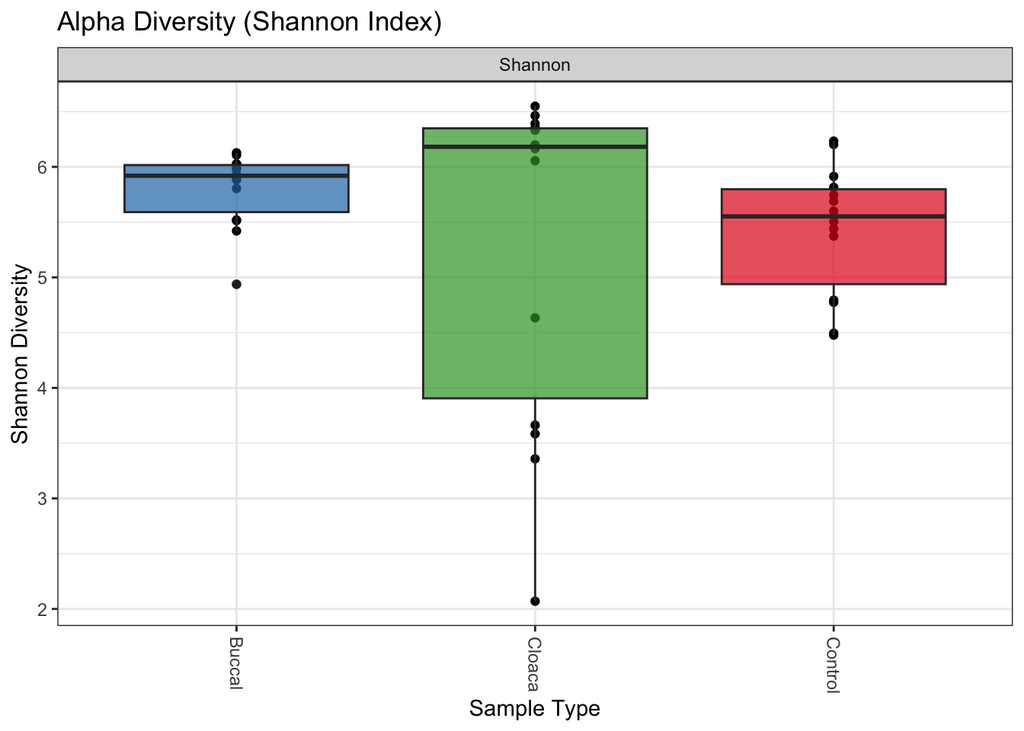

```r
alpha_plot <- plot_richness(physeq_final, x = "SampleType", measures = c("Shannon")) +
  geom_boxplot(aes(fill = SampleType), alpha = 0.7) +
  scale_fill_manual(values = sample_type_cols, name = "Sample Type") +
  labs(title = "Alpha Diversity (Shannon Index)", x = "Sample Type", y = "Shannon Diversity") +
  theme(legend.position = "none")

print(alpha_plot)
```

**Statistical Test:** We use the Kruskal-Wallis test to determine if the observed differences in Shannon diversity are statistically significant.

```r
alpha_data <- estimate_richness(physeq_final, measures = "Shannon")
alpha_data$SampleType <- sample_data(physeq_final)$SampleType

kruskal_test_result <- kruskal_test(data = alpha_data, Shannon ~ SampleType)

knitr::kable(kruskal_test_result, caption = "Kruskal-Wallis test for Shannon Diversity")
```

Kruskal-Wallis test for Shannon Diversity

| .y. | n | statistic | df | p | method |
| --- | --- | --- | --- | --- | --- |
| Shannon | 42 | 3.298529 | 2 | 0.192 | Kruskal-Wallis |

```r
print(kruskal_test_result)
```

```
## # A tibble: 1 × 6
##   .y.         n statistic    df     p method
## * <chr>   <int>     <dbl> <int> <dbl> <chr>
## 1 Shannon    42      3.30     2 0.192 Kruskal-Wallis
```